# Risk Factor Analysis

## Outcome Variable

**Outcome Variable:** wasted

## Predictor Variables

**Intervention Variable:** earlybf

**Adjustment Set:**

- arm
- sex
- W_mage
- meducyrs
- feducyrs
- hhwealth_quart
- hfoodsec
- W_mhtcm
- W_mwtkg
- W_mbmi
- vagbrth
- W_gagebrth
- W_birthwt
- W_birthlen
- W_nrooms
- W_nchldlt5
- brthmon
- W_parity
- impfloor
- impsan
- safeh20
- delta_W_mage
- delta_meducyrs
- delta_feducyrs
- delta_hhwealth_quart
- delta_hfoodsec
- delta_W_mhtcm
- delta_W_mwtkg
- delta_W_mbmi
- delta_vagbrth
- delta_W_gagebrth
- delta_W_birthwt
- delta_W_birthlen
- delta_W_nrooms
- delta_W_nchldlt5
- delta_brthmon
- delta_W_parity
- delta_impfloor
- delta_impsan
- delta_safeh20

## Stratifying Variables

The analysis was stratified on these variable(s):

- agecat
- studyid
- country

## Data Summary

| agecat | studyid | country | earlybf | wasted | n_cell | n |
| --- | --- | --- | --- | --- | --- | --- |
| Birth | EE | PAKISTAN | 1 | 0 | 34 | 170 |
| Birth | EE | PAKISTAN | 1 | 1 | 2 | 170 |
| Birth | EE | PAKISTAN | 0 | 0 | 115 | 170 |
| Birth | EE | PAKISTAN | 0 | 1 | 19 | 170 |
| Birth | GMS-Nepal | NEPAL | 1 | 0 | 129 | 586 |
| Birth | GMS-Nepal | NEPAL | 1 | 1 | 42 | 586 |
| Birth | GMS-Nepal | NEPAL | 0 | 0 | 332 | 586 |
| Birth | GMS-Nepal | NEPAL | 0 | 1 | 83 | 586 |
| Birth | JiVitA-3 | BANGLADESH | 1 | 0 | 89 | 17943 |
| Birth | JiVitA-3 | BANGLADESH | 1 | 1 | 16 | 17943 |
| Birth | JiVitA-3 | BANGLADESH | 0 | 0 | 15888 | 17943 |
| Birth | JiVitA-3 | BANGLADESH | 0 | 1 | 1950 | 17943 |
| Birth | JiVitA-4 | BANGLADESH | 1 | 0 | 1477 | 2396 |
| Birth | JiVitA-4 | BANGLADESH | 1 | 1 | 147 | 2396 |
| Birth | JiVitA-4 | BANGLADESH | 0 | 0 | 680 | 2396 |
| Birth | JiVitA-4 | BANGLADESH | 0 | 1 | 92 | 2396 |
| Birth | MAL-ED | BANGLADESH | 1 | 0 | 120 | 214 |
| Birth | MAL-ED | BANGLADESH | 1 | 1 | 20 | 214 |
| Birth | MAL-ED | BANGLADESH | 0 | 0 | 58 | 214 |
| Birth | MAL-ED | BANGLADESH | 0 | 1 | 16 | 214 |
| Birth | MAL-ED | BRAZIL | 1 | 0 | 25 | 62 |
| Birth | MAL-ED | BRAZIL | 1 | 1 | 1 | 62 |
| Birth | MAL-ED | BRAZIL | 0 | 0 | 35 | 62 |
| Birth | MAL-ED | BRAZIL | 0 | 1 | 1 | 62 |
| Birth | MAL-ED | INDIA | 1 | 0 | 27 | 44 |
| Birth | MAL-ED | INDIA | 1 | 1 | 4 | 44 |
| Birth | MAL-ED | INDIA | 0 | 0 | 12 | 44 |
| Birth | MAL-ED | INDIA | 0 | 1 | 1 | 44 |
| Birth | MAL-ED | NEPAL | 1 | 0 | 13 | 26 |
| Birth | MAL-ED | NEPAL | 1 | 1 | 1 | 26 |

[output cut: 134 more lines]

The following strata were considered:

- agecat: 24 months, studyid: EE, country: PAKISTAN
- agecat: 24 months, studyid: GMS-Nepal, country: NEPAL
- agecat: 24 months, studyid: JiVitA-3, country: BANGLADESH
- agecat: 24 months, studyid: JiVitA-4, country: BANGLADESH
- agecat: 24 months, studyid: MAL-ED, country: BANGLADESH
- agecat: 24 months, studyid: MAL-ED, country: BRAZIL
- agecat: 24 months, studyid: MAL-ED, country: INDIA
- agecat: 24 months, studyid: MAL-ED, country: NEPAL
- agecat: 24 months, studyid: MAL-ED, country: PERU
- agecat: 24 months, studyid: MAL-ED, country: SOUTH AFRICA
- agecat: 24 months, studyid: MAL-ED, country: TANZANIA, UNITED REPUBLIC OF
- agecat: 24 months, studyid: NIH-Crypto, country: BANGLADESH
- agecat: 24 months, studyid: ZVITAMBO, country: ZIMBABWE
- agecat: 6 months, studyid: EE, country: PAKISTAN
- agecat: 6 months, studyid: GMS-Nepal, country: NEPAL
- agecat: 6 months, studyid: JiVitA-3, country: BANGLADESH
- agecat: 6 months, studyid: JiVitA-4, country: BANGLADESH
- agecat: 6 months, studyid: MAL-ED, country: BANGLADESH
- agecat: 6 months, studyid: MAL-ED, country: BRAZIL
- agecat: 6 months, studyid: MAL-ED, country: INDIA
- agecat: 6 months, studyid: MAL-ED, country: NEPAL
- agecat: 6 months, studyid: MAL-ED, country: PERU
- agecat: 6 months, studyid: MAL-ED, country: SOUTH AFRICA
- agecat: 6 months, studyid: MAL-ED, country: TANZANIA, UNITED REPUBLIC OF
- agecat: 6 months, studyid: NIH-Crypto, country: BANGLADESH
- agecat: 6 months, studyid: SAS-CompFeed, country: INDIA
- agecat: 6 months, studyid: ZVITAMBO, country: ZIMBABWE
- agecat: Birth, studyid: EE, country: PAKISTAN
- agecat: Birth, studyid: GMS-Nepal, country: NEPAL
- agecat: Birth, studyid: JiVitA-3, country: BANGLADESH
- agecat: Birth, studyid: JiVitA-4, country: BANGLADESH
- agecat: Birth, studyid: MAL-ED, country: BANGLADESH
- agecat: Birth, studyid: MAL-ED, country: BRAZIL
- agecat: Birth, studyid: MAL-ED, country: INDIA
- agecat: Birth, studyid: MAL-ED, country: NEPAL
- agecat: Birth, studyid: MAL-ED, country: PERU
- agecat: Birth, studyid: MAL-ED, country: SOUTH AFRICA
- agecat: Birth, studyid: MAL-ED, country: TANZANIA, UNITED REPUBLIC OF
- agecat: Birth, studyid: NIH-Crypto, country: BANGLADESH
- agecat: Birth, studyid: SAS-CompFeed, country: INDIA
- agecat: Birth, studyid: ZVITAMBO, country: ZIMBABWE

### Dropped Strata

Some strata were dropped due to rare outcomes:

- agecat: Birth, studyid: EE, country: PAKISTAN
- agecat: Birth, studyid: MAL-ED, country: BRAZIL
- agecat: Birth, studyid: MAL-ED, country: INDIA
- agecat: Birth, studyid: MAL-ED, country: NEPAL
- agecat: Birth, studyid: MAL-ED, country: PERU
- agecat: Birth, studyid: MAL-ED, country: TANZANIA, UNITED REPUBLIC OF
- agecat: 6 months, studyid: MAL-ED, country: BANGLADESH
- agecat: 6 months, studyid: MAL-ED, country: BRAZIL
- agecat: 6 months, studyid: MAL-ED, country: NEPAL
- agecat: 6 months, studyid: MAL-ED, country: PERU
- agecat: 6 months, studyid: MAL-ED, country: SOUTH AFRICA
- agecat: 6 months, studyid: MAL-ED, country: TANZANIA, UNITED REPUBLIC OF
- agecat: 6 months, studyid: NIH-Crypto, country: BANGLADESH
- agecat: 24 months, studyid: EE, country: PAKISTAN
- agecat: 24 months, studyid: JiVitA-3, country: BANGLADESH
- agecat: 24 months, studyid: MAL-ED, country: BRAZIL
- agecat: 24 months, studyid: MAL-ED, country: NEPAL
- agecat: 24 months, studyid: MAL-ED, country: PERU
- agecat: 24 months, studyid: MAL-ED, country: SOUTH AFRICA
- agecat: 24 months, studyid: MAL-ED, country: TANZANIA, UNITED REPUBLIC OF
- agecat: 24 months, studyid: NIH-Crypto, country: BANGLADESH

## Methods Detail

We’re interested in the causal parameters $E[Y_a]$ for all values of $a \in \mathcal{A}$. These parameters represent the mean outcome if, possibly contrary to fact, we intervened to set all units to have $A=a$. Under the randomization and positivity assumptions, these are identified by the statistical parameters $\psi_a=E_W[E_{Y|A,W}(Y|A=a,W)]$. In addition, we’re interested in the mean of $Y$, $E[Y]$ under no intervention (the observed mean). We will estimate these parameters by using SuperLearner to fit the relevant likelihood factors – $E_{Y|A,W}(Y|A=a,W)$ and $p(A=a|W)$, and then updating our likelihood fit using a joint TMLE.

For unadjusted analyses ($W=\{\}$), initial likelihoods were estimated using Lrnr_glm to estimate the simple $E(Y|A)$ and Lrnr_mean to estimate $p(A)$. For adjusted analyses, a small library containing Lrnr_glmnet, Lrnr_xgboost, and Lrnr_mean was used.

Having estimated these parameters, we will then use the delta method to estimate relative risks and attributable risks relative to a prespecified baseline level of $A$.

# Results Detail

## Results Plots

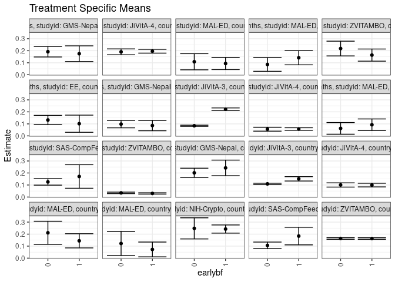

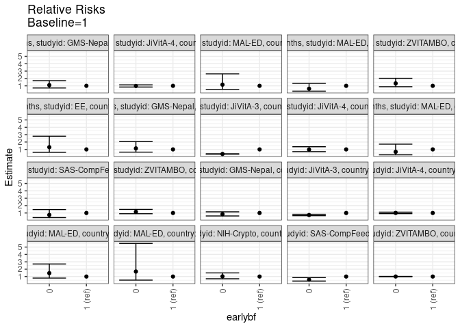

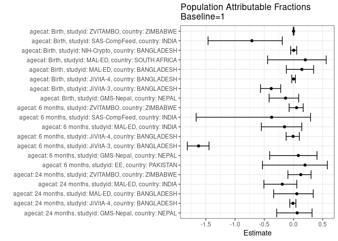

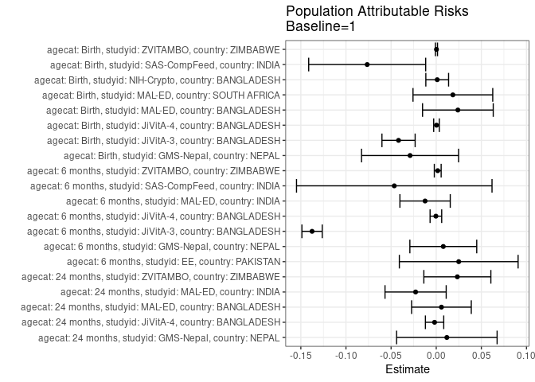

## Results Table

### Parameter: TSM

| agecat | studyid | country | intervention_level | baseline_level | estimate | ci_lower | ci_upper |
| --- | --- | --- | --- | --- | --- | --- | --- |
| Birth | GMS-Nepal | NEPAL | 1 | NA | 0.2422902 | 0.1772059 | 0.3073745 |
| Birth | GMS-Nepal | NEPAL | 0 | NA | 0.2013583 | 0.1628001 | 0.2399165 |
| Birth | JiVitA-3 | BANGLADESH | 1 | NA | 0.1513186 | 0.1332992 | 0.1693381 |
| Birth | JiVitA-3 | BANGLADESH | 0 | NA | 0.1093159 | 0.1040610 | 0.1145709 |
| Birth | JiVitA-4 | BANGLADESH | 1 | NA | 0.0994609 | 0.0842254 | 0.1146964 |
| Birth | JiVitA-4 | BANGLADESH | 0 | NA | 0.1003530 | 0.0827018 | 0.1180041 |
| Birth | MAL-ED | BANGLADESH | 1 | NA | 0.1442245 | 0.0853125 | 0.2031366 |
| Birth | MAL-ED | BANGLADESH | 0 | NA | 0.2110277 | 0.1150604 | 0.3069949 |
| Birth | MAL-ED | SOUTH AFRICA | 1 | NA | 0.0724638 | 0.0110123 | 0.1339153 |
| Birth | MAL-ED | SOUTH AFRICA | 0 | NA | 0.1219512 | 0.0213295 | 0.2225729 |
| Birth | NIH-Crypto | BANGLADESH | 1 | NA | 0.2421847 | 0.2082694 | 0.2760999 |
| Birth | NIH-Crypto | BANGLADESH | 0 | NA | 0.2477749 | 0.1599153 | 0.3356345 |
| Birth | SAS-CompFeed | INDIA | 1 | NA | 0.1837623 | 0.1104633 | 0.2570613 |
| Birth | SAS-CompFeed | INDIA | 0 | NA | 0.1062980 | 0.0787098 | 0.1338862 |
| Birth | ZVITAMBO | ZIMBABWE | 1 | NA | 0.1630139 | 0.1561825 | 0.1698453 |
| Birth | ZVITAMBO | ZIMBABWE | 0 | NA | 0.1636092 | 0.1567206 | 0.1704977 |
| 6 months | EE | PAKISTAN | 1 | NA | 0.1014493 | 0.0301120 | 0.1727866 |
| 6 months | EE | PAKISTAN | 0 | NA | 0.1322034 | 0.0934986 | 0.1709082 |
| 6 months | GMS-Nepal | NEPAL | 1 | NA | 0.0860933 | 0.0429035 | 0.1292832 |
| 6 months | GMS-Nepal | NEPAL | 0 | NA | 0.0980814 | 0.0672859 | 0.1288768 |
| 6 months | JiVitA-3 | BANGLADESH | 1 | NA | 0.2222222 | 0.2115818 | 0.2328627 |
| 6 months | JiVitA-3 | BANGLADESH | 0 | NA | 0.0843683 | 0.0794631 | 0.0892735 |
| 6 months | JiVitA-4 | BANGLADESH | 1 | NA | 0.0572748 | 0.0467214 | 0.0678283 |
| 6 months | JiVitA-4 | BANGLADESH | 0 | NA | 0.0556915 | 0.0394554 | 0.0719277 |
| 6 months | MAL-ED | INDIA | 1 | NA | 0.0928571 | 0.0446788 | 0.1410355 |
| 6 months | MAL-ED | INDIA | 0 | NA | 0.0625000 | 0.0139756 | 0.1110244 |
| 6 months | SAS-CompFeed | INDIA | 1 | NA | 0.1709216 | 0.0729186 | 0.2689247 |
| 6 months | SAS-CompFeed | INDIA | 0 | NA | 0.1258323 | 0.0989194 | 0.1527451 |
| 6 months | ZVITAMBO | ZIMBABWE | 1 | NA | 0.0298450 | 0.0245420 | 0.0351481 |
| 6 months | ZVITAMBO | ZIMBABWE | 0 | NA | 0.0344975 | 0.0283170 | 0.0406781 |
| 24 months | GMS-Nepal | NEPAL | 1 | NA | 0.1751671 | 0.1095210 | 0.2408132 |
| 24 months | GMS-Nepal | NEPAL | 0 | NA | 0.1920223 | 0.1482396 | 0.2358051 |
| 24 months | JiVitA-4 | BANGLADESH | 1 | NA | 0.1961323 | 0.1801441 | 0.2121204 |
| 24 months | JiVitA-4 | BANGLADESH | 0 | NA | 0.1907746 | 0.1662071 | 0.2153421 |
| 24 months | MAL-ED | BANGLADESH | 1 | NA | 0.0937500 | 0.0431344 | 0.1443656 |
| 24 months | MAL-ED | BANGLADESH | 0 | NA | 0.1084337 | 0.0413836 | 0.1754839 |
| 24 months | MAL-ED | INDIA | 1 | NA | 0.1417910 | 0.0825974 | 0.2009847 |
| 24 months | MAL-ED | INDIA | 0 | NA | 0.0860215 | 0.0289083 | 0.1431348 |
| 24 months | ZVITAMBO | ZIMBABWE | 1 | NA | 0.1639269 | 0.1134246 | 0.2144291 |
| 24 months | ZVITAMBO | ZIMBABWE | 0 | NA | 0.2183513 | 0.1570061 | 0.2796965 |

### Parameter: E(Y)

| agecat | studyid | country | intervention_level | baseline_level | estimate | ci_lower | ci_upper |
| --- | --- | --- | --- | --- | --- | --- | --- |
| Birth | GMS-Nepal | NEPAL | NA | NA | 0.2133106 | 0.1801152 | 0.2465060 |
| Birth | JiVitA-3 | BANGLADESH | NA | NA | 0.1095692 | 0.1044330 | 0.1147054 |
| Birth | JiVitA-4 | BANGLADESH | NA | NA | 0.0997496 | 0.0843744 | 0.1151247 |
| Birth | MAL-ED | BANGLADESH | NA | NA | 0.1682243 | 0.1179894 | 0.2184592 |
| Birth | MAL-ED | SOUTH AFRICA | NA | NA | 0.0909091 | 0.0369404 | 0.1448778 |
| Birth | NIH-Crypto | BANGLADESH | NA | NA | 0.2432815 | 0.2116319 | 0.2749310 |
| Birth | SAS-CompFeed | INDIA | NA | NA | 0.1072761 | 0.0774575 | 0.1370947 |
| Birth | ZVITAMBO | ZIMBABWE | NA | NA | 0.1632795 | 0.1565278 | 0.1700311 |
| 6 months | EE | PAKISTAN | NA | NA | 0.1263736 | 0.0921925 | 0.1605547 |
| 6 months | GMS-Nepal | NEPAL | NA | NA | 0.0939335 | 0.0686141 | 0.1192529 |
| 6 months | JiVitA-3 | BANGLADESH | NA | NA | 0.0846640 | 0.0798626 | 0.0894653 |
| 6 months | JiVitA-4 | BANGLADESH | NA | NA | 0.0569005 | 0.0480577 | 0.0657432 |
| 6 months | MAL-ED | INDIA | NA | NA | 0.0805085 | 0.0457221 | 0.1152948 |
| 6 months | SAS-CompFeed | INDIA | NA | NA | 0.1244378 | 0.0992652 | 0.1496104 |
| 6 months | ZVITAMBO | ZIMBABWE | NA | NA | 0.0315107 | 0.0275707 | 0.0354506 |
| 24 months | GMS-Nepal | NEPAL | NA | NA | 0.1869369 | 0.1506328 | 0.2232411 |
| 24 months | JiVitA-4 | BANGLADESH | NA | NA | 0.1942978 | 0.1810880 | 0.2075076 |
| 24 months | MAL-ED | BANGLADESH | NA | NA | 0.0995261 | 0.0590366 | 0.1400156 |
| 24 months | MAL-ED | INDIA | NA | NA | 0.1189427 | 0.0767376 | 0.1611478 |
| 24 months | ZVITAMBO | ZIMBABWE | NA | NA | 0.1873351 | 0.1480011 | 0.2266690 |

### Parameter: RR

| agecat | studyid | country | intervention_level | baseline_level | estimate | ci_lower | ci_upper |
| --- | --- | --- | --- | --- | --- | --- | --- |
| Birth | GMS-Nepal | NEPAL | 1 | 1 | 1.0000000 | 1.0000000 | 1.0000000 |
| Birth | GMS-Nepal | NEPAL | 0 | 1 | 0.8310625 | 0.5975843 | 1.1557614 |
| Birth | JiVitA-3 | BANGLADESH | 1 | 1 | 1.0000000 | 1.0000000 | 1.0000000 |
| Birth | JiVitA-3 | BANGLADESH | 0 | 1 | 0.7224221 | 0.6349399 | 0.8219577 |
| Birth | JiVitA-4 | BANGLADESH | 1 | 1 | 1.0000000 | 1.0000000 | 1.0000000 |
| Birth | JiVitA-4 | BANGLADESH | 0 | 1 | 1.0089690 | 0.9152938 | 1.1122314 |
| Birth | MAL-ED | BANGLADESH | 1 | 1 | 1.0000000 | 1.0000000 | 1.0000000 |
| Birth | MAL-ED | BANGLADESH | 0 | 1 | 1.4631885 | 0.7918865 | 2.7035701 |
| Birth | MAL-ED | SOUTH AFRICA | 1 | 1 | 1.0000000 | 1.0000000 | 1.0000000 |
| Birth | MAL-ED | SOUTH AFRICA | 0 | 1 | 1.6829268 | 0.5154797 | 5.4943827 |
| Birth | NIH-Crypto | BANGLADESH | 1 | 1 | 1.0000000 | 1.0000000 | 1.0000000 |
| Birth | NIH-Crypto | BANGLADESH | 0 | 1 | 1.0230827 | 0.6989169 | 1.4976006 |
| Birth | SAS-CompFeed | INDIA | 1 | 1 | 1.0000000 | 1.0000000 | 1.0000000 |
| Birth | SAS-CompFeed | INDIA | 0 | 1 | 0.5784538 | 0.3911144 | 0.8555267 |
| Birth | ZVITAMBO | ZIMBABWE | 1 | 1 | 1.0000000 | 1.0000000 | 1.0000000 |
| Birth | ZVITAMBO | ZIMBABWE | 0 | 1 | 1.0036515 | 0.9890863 | 1.0184313 |
| 6 months | EE | PAKISTAN | 1 | 1 | 1.0000000 | 1.0000000 | 1.0000000 |
| 6 months | EE | PAKISTAN | 0 | 1 | 1.3031477 | 0.6084070 | 2.7912135 |
| 6 months | GMS-Nepal | NEPAL | 1 | 1 | 1.0000000 | 1.0000000 | 1.0000000 |
| 6 months | GMS-Nepal | NEPAL | 0 | 1 | 1.1392444 | 0.6299531 | 2.0602769 |
| 6 months | JiVitA-3 | BANGLADESH | 1 | 1 | 1.0000000 | 1.0000000 | 1.0000000 |
| 6 months | JiVitA-3 | BANGLADESH | 0 | 1 | 0.3796573 | 0.3526532 | 0.4087292 |
| 6 months | JiVitA-4 | BANGLADESH | 1 | 1 | 1.0000000 | 1.0000000 | 1.0000000 |
| 6 months | JiVitA-4 | BANGLADESH | 0 | 1 | 0.9723559 | 0.6936356 | 1.3630732 |
| 6 months | MAL-ED | INDIA | 1 | 1 | 1.0000000 | 1.0000000 | 1.0000000 |
| 6 months | MAL-ED | INDIA | 0 | 1 | 0.6730769 | 0.2645580 | 1.7124128 |
| 6 months | SAS-CompFeed | INDIA | 1 | 1 | 1.0000000 | 1.0000000 | 1.0000000 |
| 6 months | SAS-CompFeed | INDIA | 0 | 1 | 0.7361986 | 0.3697876 | 1.4656746 |
| 6 months | ZVITAMBO | ZIMBABWE | 1 | 1 | 1.0000000 | 1.0000000 | 1.0000000 |
| 6 months | ZVITAMBO | ZIMBABWE | 0 | 1 | 1.1558881 | 0.8983466 | 1.4872625 |
| 24 months | GMS-Nepal | NEPAL | 1 | 1 | 1.0000000 | 1.0000000 | 1.0000000 |
| 24 months | GMS-Nepal | NEPAL | 0 | 1 | 1.0962238 | 0.7075182 | 1.6984815 |
| 24 months | JiVitA-4 | BANGLADESH | 1 | 1 | 1.0000000 | 1.0000000 | 1.0000000 |
| 24 months | JiVitA-4 | BANGLADESH | 0 | 1 | 0.9726835 | 0.8359784 | 1.1317437 |
| 24 months | MAL-ED | BANGLADESH | 1 | 1 | 1.0000000 | 1.0000000 | 1.0000000 |
| 24 months | MAL-ED | BANGLADESH | 0 | 1 | 1.1566265 | 0.5089650 | 2.6284418 |
| 24 months | MAL-ED | INDIA | 1 | 1 | 1.0000000 | 1.0000000 | 1.0000000 |
| 24 months | MAL-ED | INDIA | 0 | 1 | 0.6066780 | 0.2769161 | 1.3291323 |
| 24 months | ZVITAMBO | ZIMBABWE | 1 | 1 | 1.0000000 | 1.0000000 | 1.0000000 |
| 24 months | ZVITAMBO | ZIMBABWE | 0 | 1 | 1.3320044 | 0.8787187 | 2.0191168 |

### Parameter: PAR

| agecat | studyid | country | intervention_level | baseline_level | estimate | ci_lower | ci_upper |
| --- | --- | --- | --- | --- | --- | --- | --- |
| Birth | GMS-Nepal | NEPAL | 1 | NA | -0.0289796 | -0.0827253 | 0.0247661 |
| Birth | JiVitA-3 | BANGLADESH | 1 | NA | -0.0417495 | -0.0601327 | -0.0233662 |
| Birth | JiVitA-4 | BANGLADESH | 1 | NA | 0.0002887 | -0.0028119 | 0.0033892 |
| Birth | MAL-ED | BANGLADESH | 1 | NA | 0.0239998 | -0.0151566 | 0.0631562 |
| Birth | MAL-ED | SOUTH AFRICA | 1 | NA | 0.0184453 | -0.0257292 | 0.0626198 |
| Birth | NIH-Crypto | BANGLADESH | 1 | NA | 0.0010968 | -0.0115167 | 0.0137103 |
| Birth | SAS-CompFeed | INDIA | 1 | NA | -0.0764862 | -0.1412938 | -0.0116785 |
| Birth | ZVITAMBO | ZIMBABWE | 1 | NA | 0.0002655 | -0.0009017 | 0.0014328 |
| 6 months | EE | PAKISTAN | 1 | NA | 0.0249244 | -0.0408632 | 0.0907119 |
| 6 months | GMS-Nepal | NEPAL | 1 | NA | 0.0078401 | -0.0291997 | 0.0448799 |
| 6 months | JiVitA-3 | BANGLADESH | 1 | NA | -0.1375583 | -0.1488080 | -0.1263085 |
| 6 months | JiVitA-4 | BANGLADESH | 1 | NA | -0.0003744 | -0.0068096 | 0.0060609 |
| 6 months | MAL-ED | INDIA | 1 | NA | -0.0123487 | -0.0402294 | 0.0155320 |
| 6 months | SAS-CompFeed | INDIA | 1 | NA | -0.0464838 | -0.1547824 | 0.0618147 |
| 6 months | ZVITAMBO | ZIMBABWE | 1 | NA | 0.0016656 | -0.0021253 | 0.0054565 |
| 24 months | GMS-Nepal | NEPAL | 1 | NA | 0.0117698 | -0.0439048 | 0.0674445 |
| 24 months | JiVitA-4 | BANGLADESH | 1 | NA | -0.0018345 | -0.0119918 | 0.0083228 |
| 24 months | MAL-ED | BANGLADESH | 1 | NA | 0.0057761 | -0.0272847 | 0.0388368 |
| 24 months | MAL-ED | INDIA | 1 | NA | -0.0228483 | -0.0567365 | 0.0110399 |
| 24 months | ZVITAMBO | ZIMBABWE | 1 | NA | 0.0234082 | -0.0137178 | 0.0605343 |

### Parameter: PAF

| agecat | studyid | country | intervention_level | baseline_level | estimate | ci_lower | ci_upper |
| --- | --- | --- | --- | --- | --- | --- | --- |
| Birth | GMS-Nepal | NEPAL | 1 | NA | -0.1358564 | -0.4172388 | 0.0896597 |
| Birth | JiVitA-3 | BANGLADESH | 1 | NA | -0.3810328 | -0.5646698 | -0.2189482 |
| Birth | JiVitA-4 | BANGLADESH | 1 | NA | 0.0028941 | -0.0286150 | 0.0334381 |
| Birth | MAL-ED | BANGLADESH | 1 | NA | 0.1426654 | -0.1215347 | 0.3446278 |
| Birth | MAL-ED | SOUTH AFRICA | 1 | NA | 0.2028986 | -0.4432286 | 0.5597574 |
| Birth | NIH-Crypto | BANGLADESH | 1 | NA | 0.0045084 | -0.0487081 | 0.0550245 |
| Birth | SAS-CompFeed | INDIA | 1 | NA | -0.7129840 | -1.4626670 | -0.1915189 |
| Birth | ZVITAMBO | ZIMBABWE | 1 | NA | 0.0016263 | -0.0055475 | 0.0087490 |
| 6 months | EE | PAKISTAN | 1 | NA | 0.1972275 | -0.5313880 | 0.5791767 |
| 6 months | GMS-Nepal | NEPAL | 1 | NA | 0.0834646 | -0.4075351 | 0.4031857 |
| 6 months | JiVitA-3 | BANGLADESH | 1 | NA | -1.6247556 | -1.8169228 | -1.4456979 |
| 6 months | JiVitA-4 | BANGLADESH | 1 | NA | -0.0065794 | -0.1263628 | 0.1004656 |
| 6 months | MAL-ED | INDIA | 1 | NA | -0.1533835 | -0.5504312 | 0.1419849 |
| 6 months | SAS-CompFeed | INDIA | 1 | NA | -0.3735509 | -1.6658955 | 0.2923046 |
| 6 months | ZVITAMBO | ZIMBABWE | 1 | NA | 0.0528590 | -0.0751812 | 0.1656512 |
| 24 months | GMS-Nepal | NEPAL | 1 | NA | 0.0629615 | -0.2875288 | 0.3180416 |
| 24 months | JiVitA-4 | BANGLADESH | 1 | NA | -0.0094415 | -0.0631554 | 0.0415586 |
| 24 months | MAL-ED | BANGLADESH | 1 | NA | 0.0580357 | -0.3393097 | 0.3374970 |
| 24 months | MAL-ED | INDIA | 1 | NA | -0.1920951 | -0.5068616 | 0.0569202 |
| 24 months | ZVITAMBO | ZIMBABWE | 1 | NA | 0.1249538 | -0.0954088 | 0.3009863 |